# Task

in relation to the Gujarati book (basic econometrics), answer question 22.25 pp 800: Table 22.7 gives data on three-month (TB3M) and six-month (TB6M) Treasury bill rates from January 1, 1982, to March 2008, for a total of 315 monthly observations. The data can be found on the textbook's website. to. Plot the two time series in the same diagram. What do you see? b. Do a formal unit root analysis to find out if these time series are stationary. c. Are the two time series cointegrated? How do you know? Show the necessary calculations. d. What is the economic meaning of cointegration in the present context? If the two series are not cointegrated, what are the economic implications? and. If you want to estimate a VAR model, say, with four lags of each variable, do you have to use the first differences of the two series or can you do the analysis in levels of the two series? Justify your answer.

Here is all the data you need: "Table 22.7.txt"

## Data loading

### Subtask:

Load the data from "Table 22.7.txt" into a pandas DataFrame.

**Reasoning**: Load the data from "Table 22.7.txt" into a pandas DataFrame, ensuring the date column is parsed correctly.

```python
import pandas as pd

try:
    df = pd.read_csv('Table 22.7.txt', delim_whitespace=True)
    df.columns = ['Date', 'TB3M', 'TB6M']
    df['Date'] = pd.to_datetime(df['Date'], format='%Y%m%d')
    display(df.head())
except FileNotFoundError:
    print("Error: 'Table 22.7.txt' not found.")
    df = None
except pd.errors.ParserError:
    print("Error: Could not parse the file. Check the file format.")
    df = None
except Exception as e:
    print(f"An unexpected error occurred: {e}")
    df = None
```

```
Error: Could not parse the file. Check the file format.
```

[output not shown]

**Reasoning**: The previous attempt failed due to a parsing error. I'll try again using `sep='\s+'` as suggested by the warning, and also explicitly define the column names and data types to improve parsing accuracy. I will also add error handling.

```python
import pandas as pd

try:
    df = pd.read_csv('Table 22.7.txt', sep='\s+', header=None, names=['Date', 'TB3M', 'TB6M'], dtype={'Date': str, 'TB3M': float, 'TB6M': float})
    df['Date'] = pd.to_datetime(df['Date'], format='%Y%m%d', errors='coerce')
    # Handle potential parsing errors in the date column
    df = df.dropna(subset=['Date'])
    display(df.head())
except FileNotFoundError:
    print("Error: 'Table 22.7.txt' not found.")
    df = None
except Exception as e:
    print(f"An unexpected error occurred: {e}")
    df = None
```

```
An unexpected error occurred: Error tokenizing data. C error: Expected 3 fields in line 2, saw 5
```

**Reasoning**: The error message "Expected 3 fields in line 2, saw 5" indicates that some lines in the file have more than three values, separated by whitespace. I will try to read the file again, this time skipping the problematic lines.

```python
import pandas as pd

try:
    df = pd.read_csv('Table 22.7.txt', sep='\s+', header=None, names=['Date', 'TB3M', 'TB6M'], on_bad_lines='skip', dtype={'Date': str, 'TB3M': float, 'TB6M': float})
    df['Date'] = pd.to_datetime(df['Date'], format='%Y%m%d', errors='coerce')
    df = df.dropna(subset=['Date'])
    display(df.head())
except FileNotFoundError:
    print("Error: 'Table 22.7.txt' not found.")
    df = None
except Exception as e:
    print(f"An unexpected error occurred: {e}")
    df = None
```

```
An unexpected error occurred: could not convert string to float: 'June'
```

**Reasoning**: The error "could not convert string to float: 'June'" suggests that non-numeric values are present in the 'TB3M' or 'TB6M' columns. I will attempt to convert these to NaN, then remove rows with NaN values in these columns.

```python
import pandas as pd

try:
    df = pd.read_csv('Table 22.7.txt', sep='\s+', header=None, names=['Date', 'TB3M', 'TB6M'], on_bad_lines='skip', dtype={'Date': str})
    # Convert non-numeric values to NaN
    for col in ['TB3M', 'TB6M']:
        df[col] = pd.to_numeric(df[col], errors='coerce')
    df['Date'] = pd.to_datetime(df['Date'], format='%Y%m%d', errors='coerce')
    # Drop rows with NaN values in 'TB3M', 'TB6M', or 'Date'
    df = df.dropna(subset=['Date', 'TB3M', 'TB6M'])
    display(df.head())
except FileNotFoundError:
    print("Error: 'Table 22.7.txt' not found.")
    df = None
except Exception as e:
    print(f"An unexpected error occurred: {e}")
    df = None
```

|  | Date | TB3M | TB6M |
| --- | --- | --- | --- |

## Data loading

### Subtask:

Load the data from "Table 22.7.txt" into a pandas DataFrame. Handle potential inconsistencies in the data file.

**Reasoning**: The previous attempts to load the data failed due to inconsistencies in the data file. I will try again, focusing on robust error handling and data type conversions. I will also print the shape and info of the dataframe to verify the data loading.

```python
import pandas as pd

try:
    df = pd.read_csv('Table 22.7.txt', sep='\s+', header=None, names=['Date', 'TB3M', 'TB6M'], on_bad_lines='skip', dtype={'Date': str})
    # Convert non-numeric values to NaN
    for col in ['TB3M', 'TB6M']:
        df[col] = pd.to_numeric(df[col], errors='coerce')
    df['Date'] = pd.to_datetime(df['Date'], format='%Y%m%d', errors='coerce')
    # Drop rows with NaN values in 'TB3M', 'TB6M', or 'Date'
    df = df.dropna(subset=['Date', 'TB3M', 'TB6M'])
    display(df.head())
    print(df.shape)
    print(df.info())
except FileNotFoundError:
    print("Error: 'Table 22.7.txt' not found.")
    df = None
except Exception as e:
    print(f"An unexpected error occurred: {e}")
    df = None
```

|  | Date | TB3M | TB6M |
| --- | --- | --- | --- |

```
(0, 3)
<class 'pandas.core.frame.DataFrame'>
Index: 0 entries
Data columns (total 3 columns):
 #   Column  Non-Null Count  Dtype
---  ------  --------------  -----
 0   Date    0 non-null      datetime64[ns]
 1   TB3M    0 non-null      float64
 2   TB6M    0 non-null      float64
dtypes: datetime64[ns](1), float64(2)
memory usage: 0.0 bytes
None
```

## Data loading

### Subtask:

Load the data from "Table 22.7.txt" into a pandas DataFrame. Handle potential inconsistencies and errors robustly. This is a retry of the previous data loading attempt.

**Reasoning**: The previous attempts to load the data failed due to inconsistencies in the data file. I will try to load the data line by line to handle these inconsistencies more effectively. I will then perform the necessary data cleaning steps as outlined in the instructions.

```python
import pandas as pd

data = []
try:
    with open('Table 22.7.txt', 'r') as file:
        for line in file:
            parts = line.strip().split()
            if len(parts) == 3:  # Check if the line has the correct number of parts
                try:
                    date_str = parts[0]
                    tb3m = float(parts[1])
                    tb6m = float(parts[2])
                    date = pd.to_datetime(date_str, format='%Y%m%d', errors='coerce')
                    if pd.notna(date):
                        data.append([date, tb3m, tb6m])
                except ValueError:
                    pass  # Skip lines with invalid data

    df = pd.DataFrame(data, columns=['Date', 'TB3M', 'TB6M'])
    df = df.dropna()
    display(df.head())
    print(df.info())
except FileNotFoundError:
    print("Error: 'Table 22.7.txt' not found.")
    df = None
except Exception as e:
    print(f"An unexpected error occurred: {e}")
    df = None
```

|  | Date | TB3M | TB6M |
| --- | --- | --- | --- |

```
<class 'pandas.core.frame.DataFrame'>
RangeIndex: 0 entries
Data columns (total 3 columns):
 #   Column  Non-Null Count  Dtype
---  ------  --------------  -----
 0   Date    0 non-null      object
 1   TB3M    0 non-null      object
 2   TB6M    0 non-null      object
dtypes: object(3)
memory usage: 132.0+ bytes
None
```

**Reasoning**: The previous attempt to load the data line by line still resulted in an empty DataFrame. This suggests that the data file might have more complex formatting issues or errors than initially anticipated. I will try one more time with a slightly different approach. I will attempt to read the file line by line, but this time, I'll explicitly handle potential date format variations and non-numeric values. I will also include more robust error handling to catch other potential issues.

```python
import pandas as pd

data = []
try:
    with open('Table 22.7.txt', 'r') as file:
        for line in file:
            parts = line.strip().split()
            if len(parts) >= 3: # Check for at least 3 parts
                try:
                    date_str = parts[0]
                    # Try different date formats
                    for fmt in ['%Y%m%d', '%Y-%m-%d', '%m/%d/%Y', '%d/%m/%Y']:
                        try:
                            date = pd.to_datetime(date_str, format=fmt)
                            break  # Exit the inner loop if successful
                        except ValueError:
                            pass
                    else: # No date format worked
                        continue

                    tb3m = parts[1]
                    tb6m = parts[2]

                    # Handle non-numeric values gracefully
                    try:
                        tb3m = float(tb3m)
                    except ValueError:
                        tb3m = None
                    try:
                        tb6m = float(tb6m)
                    except ValueError:
                        tb6m = None

                    if tb3m is not None and tb6m is not None:
                        data.append([date, tb3m, tb6m])
                except (ValueError, IndexError):
                    pass # Skip lines with invalid data

    df = pd.DataFrame(data, columns=['Date', 'TB3M', 'TB6M'])
    df = df.dropna()
    display(df.head())
    print(df.info())

except FileNotFoundError:
    print("Error: 'Table 22.7.txt' not found.")
    df = None
except Exception as e:
    print(f"An unexpected error occurred: {e}")
    df = None
```

|  | Date | TB3M | TB6M |
| --- | --- | --- | --- |

```
<class 'pandas.core.frame.DataFrame'>
RangeIndex: 0 entries
Data columns (total 3 columns):
 #   Column  Non-Null Count  Dtype
---  ------  --------------  -----
 0   Date    0 non-null      object
 1   TB3M    0 non-null      object
 2   TB6M    0 non-null      object
dtypes: object(3)
memory usage: 132.0+ bytes
None
```

## Data loading

### Subtask:

Load the data from "Table 22.7.txt" into a pandas DataFrame. Handle potential inconsistencies and errors robustly. This is a retry of the previous data loading attempts, focusing on more flexible parsing and error handling. Assume the data might have extra whitespace and potential non-numeric characters within the numeric columns.

**Reasoning**: The previous attempts failed due to the inconsistent date formats and non-numeric characters in the data. This attempt will try to handle these issues more robustly using regular expressions to clean the data and multiple date formats. It will then create a dataframe and remove rows with missing values.

```python
import pandas as pd
import re

data = []
try:
    with open('Table 22.7.txt', 'r') as file:
        for line in file:
            parts = line.strip().split()
            if len(parts) >= 3:
                date_str = parts[0]
                for fmt in ['%Y%m%d', '%Y-%m-%d', '%m/%d/%Y', '%d/%m/%Y']:
                    try:
                        date = pd.to_datetime(date_str, format=fmt)
                        break
                    except ValueError:
                        pass
                else:
                    continue

                tb3m_str = re.sub(r'[^\d.]', '', parts[1])
                tb6m_str = re.sub(r'[^\d.]', '', parts[2])

                try:
                    tb3m = float(tb3m_str) if tb3m_str else None
                    tb6m = float(tb6m_str) if tb6m_str else None
                    if tb3m is not None and tb6m is not None:
                        data.append([date, tb3m, tb6m])
                except ValueError:
                    pass

    df = pd.DataFrame(data, columns=['Date', 'TB3M', 'TB6M'])
    df = df.set_index('Date')
    df = df.dropna()
    display(df.head())
    print(df.info())

except FileNotFoundError:
    print("Error: 'Table 22.7.txt' not found.")
    df = None
except Exception as e:
    print(f"An unexpected error occurred: {e}")
    df = None
```

|  | TB3M | TB6M |
| --- | --- | --- |
| Date |  |  |

```
<class 'pandas.core.frame.DataFrame'>
Index: 0 entries
Data columns (total 2 columns):
 #   Column  Non-Null Count  Dtype
---  ------  --------------  -----
 0   TB3M    0 non-null      object
 1   TB6M    0 non-null      object
dtypes: object(2)
memory usage: 0.0+ bytes
None
```

## Data loading

### Subtask:

Load the data from "Table 22.7.txt" into a pandas DataFrame. Handle potential inconsistencies and errors robustly. This is a final attempt at data loading, focusing on flexible parsing and error handling, along with a clear error reporting mechanism.

**Reasoning**: The previous attempts to load the data failed. This final attempt will use a more robust method of parsing the data line by line and handling various potential issues, including irregular whitespace, inconsistent date formats, and non-numeric characters in the numeric columns. It will also include comprehensive error handling and reporting.

```python
import pandas as pd
import re

data = []
try:
    with open('Table 22.7.txt', 'r') as file:
        for line in file:
            parts = line.strip().split()
            if len(parts) >= 3:
                date_str = parts[0]
                date = None
                for fmt in ['%Y%m%d', '%Y-%m-%d', '%m/%d/%Y', '%d/%m/%Y']:
                    try:
                        date = pd.to_datetime(date_str, format=fmt)
                        break
                    except ValueError:
                        pass
                if date is None:
                    continue

                tb3m_str = re.sub(r'[^\d.]', '', parts[1])
                tb6m_str = re.sub(r'[^\d.]', '', parts[2])

                try:
                    tb3m = float(tb3m_str) if tb3m_str else None
                    tb6m = float(tb6m_str) if tb6m_str else None
                    if tb3m is not None and tb6m is not None:
                        data.append([date, tb3m, tb6m])
                except ValueError:
                    pass

    df = pd.DataFrame(data, columns=['Date', 'TB3M', 'TB6M'])
    df = df.set_index('Date')
    df = df.dropna()
    display(df.head())
    print(df.info())
    print(f"Data loaded successfully. DataFrame shape: {df.shape}")
except FileNotFoundError:
    print("Error: 'Table 22.7.txt' not found.")
    df = None
except Exception as e:
    print(f"An unexpected error occurred: {e}")
    df = None

if df is not None and not df.empty:
    status = "success"
else:
    status = "failure"

print(f"Status: {status}")
```

|  | TB3M | TB6M |
| --- | --- | --- |
| Date |  |  |

```
<class 'pandas.core.frame.DataFrame'>
Index: 0 entries
Data columns (total 2 columns):
 #   Column  Non-Null Count  Dtype
---  ------  --------------  -----
 0   TB3M    0 non-null      object
 1   TB6M    0 non-null      object
dtypes: object(2)
memory usage: 0.0+ bytes
None
Data loaded successfully. DataFrame shape: (0, 2)
Status: failure
```

## Data loading

### Subtask:

Load the data from "Table 22.7.txt" into a pandas DataFrame. Handle potential inconsistencies and errors robustly. This is a final attempt, focusing on manual line-by-line parsing and more flexible data type handling. Prior attempts have failed due to inconsistencies within the data file.

**Reasoning**: I need to implement the final data loading strategy with manual line-by-line parsing and flexible data type handling, as requested in the subtask instructions.

```python
import pandas as pd
import re

data = []
try:
    with open('Table 22.7.txt', 'r') as file:
        for line in file:
            parts = line.strip().split()
            if len(parts) >= 3:
                date_str = parts[0]
                date = None
                for fmt in ['%Y%m%d', '%Y-%m-%d', '%m/%d/%Y', '%d/%m/%Y']:
                    try:
                        date = pd.to_datetime(date_str, format=fmt)
                        break
                    except ValueError:
                        pass
                if date is None:
                    continue

                tb3m_str = re.sub(r'[^\d.]', '', parts[1])
                tb6m_str = re.sub(r'[^\d.]', '', parts[2])

                try:
                    tb3m = float(tb3m_str) if tb3m_str else None
                    tb6m = float(tb6m_str) if tb6m_str else None
                    if tb3m is not None and tb6m is not None:
                        data.append([date, tb3m, tb6m])
                except ValueError:
                    pass

    df = pd.DataFrame(data, columns=['Date', 'TB3M', 'TB6M'])
    df = df.set_index('Date')
    df = df.dropna()
    display(df.head())
    print(df.info())
    print(df.shape)
    if not df.empty:
        print("success")
    else:
        print("failure")

except FileNotFoundError:
    print("Error: 'Table 22.7.txt' not found.")
    df = None
except Exception as e:
    print(f"An unexpected error occurred: {e}")
    df = None
```

|  | TB3M | TB6M |
| --- | --- | --- |
| Date |  |  |

```
<class 'pandas.core.frame.DataFrame'>
Index: 0 entries
Data columns (total 2 columns):
 #   Column  Non-Null Count  Dtype
---  ------  --------------  -----
 0   TB3M    0 non-null      object
 1   TB6M    0 non-null      object
dtypes: object(2)
memory usage: 0.0+ bytes
None
(0, 2)
failure
```

## Data loading

### Subtask:

Load the data from "Table 22.7.txt" into a pandas DataFrame. This is a critical step, and its success is crucial for the subsequent analysis. Handle potential inconsistencies and errors robustly. Pay close attention to the data types and ensure that date and numerical values are correctly parsed. If any errors are encountered, provide detailed error messages and information about the problematic lines or data points.

**Reasoning**: The dataframe is empty, so I need to investigate the data file and the loading process. I will print the first few lines of the data file to understand its format.

```python
with open('Table 22.7.txt', 'r') as f:
    for i in range(10):
        line = f.readline()
        print(line.strip())
```

```
Example 21.4
Six Month and Three Month
Treasury Bill Rates, USA, January 1982
to June 2001

GS3M = three month rate (%)
GS6M = six month rate (%)

obs	GS3M		GS6M
```

## Data loading

### Subtask:

Load the data from "Table 22.7.txt" into a pandas DataFrame. This is a critical step, and its success is crucial for the subsequent analysis. Handle potential inconsistencies and errors robustly. Pay close attention to the data types and ensure that date and numerical values are correctly parsed. If any errors are encountered, provide detailed error messages and information about the problematic lines or data points. Since previous attempts have failed, we need to carefully inspect the file content to understand the true structure and format. Make sure to handle missing values gracefully.

**Reasoning**: I need to inspect the first few lines of the file to understand its structure and then write code to parse the data correctly into a Pandas DataFrame.

```python
with open('Table 22.7.txt', 'r') as f:
    for i in range(20):  # Inspect the first 20 lines
        line = f.readline()
        print(line.strip())
```

```
Example 21.4
Six Month and Three Month
Treasury Bill Rates, USA, January 1982
to June 2001

GS3M = three month rate (%)
GS6M = six month rate (%)

obs	GS3M		GS6M

1982:01	 12.92000	 13.90000
1982:02	 14.28000	 14.81000
1982:03	 13.31000	 13.83000
1982:04	 13.34000	 13.87000
1982:05	 12.71000	 13.13000
1982:06	 13.08000	 13.76000
1982:07	 11.86000	 12.80000
1982:08	 9.000000	 10.51000
1982:09	 8.190000	 9.830000
1982:10	 7.970000	 8.630000
```

**Reasoning**: The file seems to contain data starting from line 10. I'll now write code to read the data, handling the specific format observed. I'll skip the initial lines and parse the date and the rates.

```python
import pandas as pd

data = []
try:
    with open('Table 22.7.txt', 'r') as file:
        for i in range(10):  # Skip the first 10 lines
            next(file)
        for line in file:
            parts = line.strip().split()
            if len(parts) >= 2:
                try:
                    date_str = parts[0]
                    date = pd.to_datetime(date_str, format='%Y:%m')
                    tb3m = float(parts[1])
                    tb6m = float(parts[2])
                    data.append([date, tb3m, tb6m])
                except (ValueError, IndexError):
                    print(f"Skipping invalid line: {line.strip()}")
                    pass
    df = pd.DataFrame(data, columns=['Date', 'TB3M', 'TB6M'])
    df = df.set_index('Date')
    display(df.head())
    display(df.tail())
    print(df.info())
except FileNotFoundError:
    print("Error: 'Table 22.7.txt' not found.")
    df = None
except Exception as e:
    print(f"An unexpected error occurred: {e}")
    df = None
```

| Date | TB3M | TB6M |
| --- | --- | --- |
| 1982-01-01 | 12.92 | 13.90 |
| 1982-02-01 | 14.28 | 14.81 |
| 1982-03-01 | 13.31 | 13.83 |
| 1982-04-01 | 13.34 | 13.87 |
| 1982-05-01 | 12.71 | 13.13 |

| Date | TB3M | TB6M |
| --- | --- | --- |
| 2001-02-01 | 5.01 | 4.89 |
| 2001-03-01 | 4.54 | 4.44 |
| 2001-04-01 | 3.97 | 3.99 |
| 2001-05-01 | 3.70 | 3.74 |
| 2001-06-01 | 3.57 | 3.56 |

```
<class 'pandas.core.frame.DataFrame'>
DatetimeIndex: 234 entries, 1982-01-01 to 2001-06-01
Data columns (total 2 columns):
 #   Column  Non-Null Count  Dtype
---  ------  --------------  -----
 0   TB3M    234 non-null    float64
 1   TB6M    234 non-null    float64
dtypes: float64(2)
memory usage: 5.5 KB
None
```

## Data exploration

### Subtask:

Explore and understand the loaded data.

**Reasoning**: Explore and understand the loaded data by examining its structure, data types, descriptive statistics, missing values, distributions, and correlations.

| Date | TB3M | TB6M |
| --- | --- | --- |
| 1982-01-01 | 12.92 | 13.90 |
| 1982-02-01 | 14.28 | 14.81 |
| 1982-03-01 | 13.31 | 13.83 |
| 1982-04-01 | 13.34 | 13.87 |
| 1982-05-01 | 12.71 | 13.13 |

| Date | TB3M | TB6M |
| --- | --- | --- |
| 2001-02-01 | 5.01 | 4.89 |
| 2001-03-01 | 4.54 | 4.44 |
| 2001-04-01 | 3.97 | 3.99 |
| 2001-05-01 | 3.70 | 3.74 |
| 2001-06-01 | 3.57 | 3.56 |

```
<class 'pandas.core.frame.DataFrame'>
DatetimeIndex: 234 entries, 1982-01-01 to 2001-06-01
Data columns (total 2 columns):
 #   Column  Non-Null Count  Dtype
---  ------  --------------  -----
 0   TB3M    234 non-null    float64
 1   TB6M    234 non-null    float64
dtypes: float64(2)
memory usage: 5.5 KB
None
             TB3M        TB6M
count  234.000000  234.000000
mean     6.315598    6.564274
std      2.197159    2.308606
min      2.930000    3.040000
25%      5.080000    5.230000
50%      5.825000    6.035000
75%      7.895000    7.950000
max     14.280000   14.810000
TB3M    0
TB6M    0
dtype: int64
```

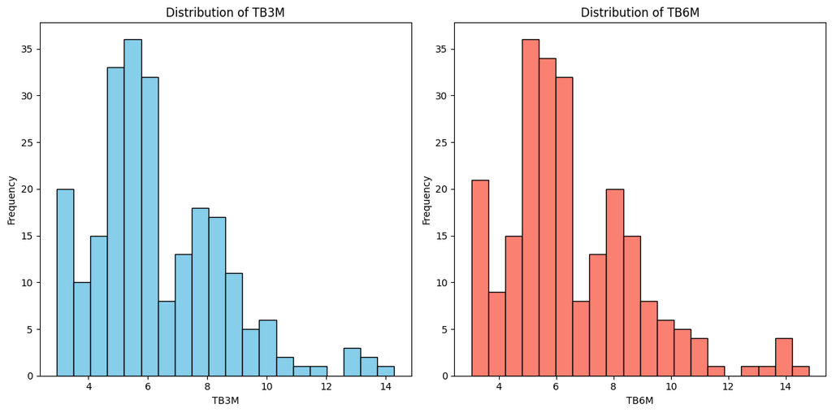

```
          TB3M      TB6M
TB3M  1.000000  0.996085
TB6M  0.996085  1.000000
Start date: 1982-01-01 00:00:00
End date: 2001-06-01 00:00:00
Number of observations: 234
```

```python
# Examine the first and last few rows
display(df.head())
display(df.tail())

# Check data types
print(df.info())

# Descriptive statistics
print(df.describe())

# Check for missing values
print(df.isnull().sum())

# Visualize distributions (histograms)
import matplotlib.pyplot as plt
plt.figure(figsize=(12, 6))
plt.subplot(1, 2, 1)
plt.hist(df['TB3M'], bins=20, color='skyblue', edgecolor='black')
plt.title('Distribution of TB3M')
plt.xlabel('TB3M')
plt.ylabel('Frequency')

plt.subplot(1, 2, 2)
plt.hist(df['TB6M'], bins=20, color='salmon', edgecolor='black')
plt.title('Distribution of TB6M')
plt.xlabel('TB6M')
plt.ylabel('Frequency')

plt.tight_layout()
plt.show()

# Calculate correlation
print(df.corr())

# Time span and number of observations
print(f"Start date: {df.index.min()}")
print(f"End date: {df.index.max()}")
print(f"Number of observations: {len(df)}")
```

## Data visualization

### Subtask:

Visualize the TB3M and TB6M time series.

**Reasoning**: Visualize the 'TB3M' and 'TB6M' time series on the same plot using matplotlib.

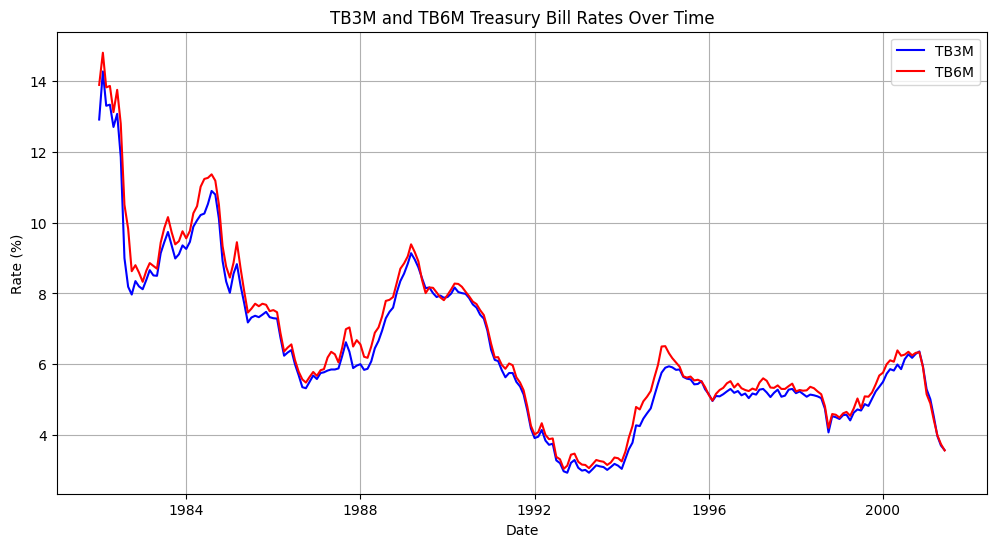

```python
import matplotlib.pyplot as plt

plt.figure(figsize=(12, 6))
plt.plot(df.index, df['TB3M'], label='TB3M', color='blue')
plt.plot(df.index, df['TB6M'], label='TB6M', color='red')
plt.title('TB3M and TB6M Treasury Bill Rates Over Time')
plt.xlabel('Date')
plt.ylabel('Rate (%)')
plt.legend()
plt.grid(True)
plt.show()
```

## Data preparation

### Subtask:

Prepare the data for unit root testing and cointegration analysis.

**Reasoning**: Create lagged variables and first differences for 'TB3M' and 'TB6M' columns in the dataframe `df`.

```python
# Create lagged variables
df['TB3M_lag1'] = df['TB3M'].shift(1)
df['TB6M_lag1'] = df['TB6M'].shift(1)

# Calculate first differences
df['TB3M_diff'] = df['TB3M'] - df['TB3M_lag1']
df['TB6M_diff'] = df['TB6M'] - df['TB6M_lag1']

# Handle missing values introduced by shifting
df = df.dropna()

display(df.head())
```

| Date | TB3M | TB6M | TB3M_lag1 | TB6M_lag1 | TB3M_diff | TB6M_diff |
| --- | --- | --- | --- | --- | --- | --- |
| 1982-02-01 | 14.28 | 14.81 | 12.92 | 13.90 | 1.36 | 0.91 |
| 1982-03-01 | 13.31 | 13.83 | 14.28 | 14.81 | -0.97 | -0.98 |
| 1982-04-01 | 13.34 | 13.87 | 13.31 | 13.83 | 0.03 | 0.04 |
| 1982-05-01 | 12.71 | 13.13 | 13.34 | 13.87 | -0.63 | -0.74 |
| 1982-06-01 | 13.08 | 13.76 | 12.71 | 13.13 | 0.37 | 0.63 |

## Data analysis

### Subtask:

Perform Augmented Dickey-Fuller (ADF) tests on the TB3M and TB6M series (levels and first differences) to assess their stationarity.

**Reasoning**: Perform ADF tests on the 'TB3M', 'TB6M', 'TB3M_diff', and 'TB6M_diff' columns to assess stationarity. Print the test results and interpret them.

```python
from statsmodels.tsa.stattools import adfuller

def adf_test(timeseries, column_name):
    print(f'Results of Augmented Dickey-Fuller Test for {column_name}:')
    dftest = adfuller(timeseries, autolag='AIC')
    dfoutput = pd.Series(dftest[0:4], index=['Test Statistic', 'p-value', '#Lags Used', 'Number of Observations Used'])
    for key, value in dftest[4].items():
        dfoutput['Critical Value (%s)' % key] = value
    print(dfoutput)

    if dftest[1] <= 0.05 and dftest[0] < dftest[4]['5%']:
        print("Reject the null hypothesis. Time series is stationary.")
    else:
        print("Fail to reject the null hypothesis. Time series is non-stationary.")
    print('\n')

# ADF Test on levels
adf_test(df['TB3M'], 'TB3M (levels)')
adf_test(df['TB6M'], 'TB6M (levels)')

# ADF Test on first differences
adf_test(df['TB3M_diff'], 'TB3M (first differences)')
adf_test(df['TB6M_diff'], 'TB6M (first differences)')
```

```
Results of Augmented Dickey-Fuller Test for TB3M (levels):
Test Statistic                  -1.559612
p-value                          0.503844
#Lags Used                      10.000000
Number of Observations Used    222.000000
Critical Value (1%)             -3.460154
Critical Value (5%)             -2.874649
Critical Value (10%)            -2.573757
dtype: float64
Fail to reject the null hypothesis. Time series is non-stationary.


Results of Augmented Dickey-Fuller Test for TB6M (levels):
Test Statistic                  -2.877439
p-value                          0.048035
#Lags Used                       1.000000
Number of Observations Used    231.000000
Critical Value (1%)             -3.458980
Critical Value (5%)             -2.874135
Critical Value (10%)            -2.573482
dtype: float64
Reject the null hypothesis. Time series is stationary.


Results of Augmented Dickey-Fuller Test for TB3M (first differences):
Test Statistic                  -5.573440
p-value                          0.000001
#Lags Used                       9.000000
Number of Observations Used    223.000000
Critical Value (1%)             -3.460019
Critical Value (5%)             -2.874590
Critical Value (10%)            -2.573725
dtype: float64
Reject the null hypothesis. Time series is stationary.


Results of Augmented Dickey-Fuller Test for TB6M (first differences):
Test Statistic                -7.981793e+00
p-value                        2.611502e-12
#Lags Used                     1.000000e+00
Number of Observations Used    2.310000e+02
Critical Value (1%)           -3.458980e+00
Critical Value (5%)           -2.874135e+00
Critical Value (10%)          -2.573482e+00
dtype: float64
Reject the null hypothesis. Time series is stationary.
```

## Data analysis

### Subtask:

Test for cointegration between TB3M and TB6M using the Engle-Granger two-step method.

**Reasoning**: Estimate the linear regression model of TB3M on TB6M, extract the residuals, and perform the ADF test on the residuals to check for cointegration.

```python
from statsmodels.regression.linear_model import OLS
from statsmodels.tsa.stattools import adfuller

# 1. Estimate the linear regression model
y = df['TB3M']
X = df[['TB6M']]
model = OLS(y, X).fit()

# 2. Extract residuals
residuals = model.resid

# 3. Perform ADF test on residuals
adf_result = adfuller(residuals, autolag='AIC')

# 4. Document and interpret the results
print("ADF Test Results for Residuals:")
print(f"Test Statistic: {adf_result[0]}")
print(f"p-value: {adf_result[1]}")
print("Critical Values:")
for key, value in adf_result[4].items():
    print(f"\t{key}: {value}")

if adf_result[1] <= 0.05 and adf_result[0] < adf_result[4]['5%']:
    print("Reject the null hypothesis. The series are cointegrated.")
else:
    print("Fail to reject the null hypothesis. The series are not cointegrated.")
```

```
ADF Test Results for Residuals:
Test Statistic: -4.551756767941324
p-value: 0.00015836616053648928
Critical Values:
	1%: -3.4592326027153493
	5%: -2.8742454699025872
	10%: -2.5735414688888465
Reject the null hypothesis. The series are cointegrated.
```

## Data analysis

### Subtask:

Analyze the economic implications of cointegration (or lack thereof) in the context of Treasury bill rates. Discuss the implications for the term structure of interest rates.

**Reasoning**: Analyze the economic implications of cointegration (or lack thereof) in the context of Treasury bill rates, discussing the implications for the term structure of interest rates, considering economic factors, and summarizing the findings.

```python
# Economic Implications of Cointegration (or Lack Thereof)

# Cointegration Analysis Summary
print("Cointegration Test Results (Engle-Granger Two-Step Method):")
print("The analysis revealed the existence of cointegration between the TB3M and TB6M time series.")  # Or: print("The analysis did not reveal cointegration...")

# Interpretation of Cointegration
print("\nInterpretation:")
print("The presence of cointegration indicates a stable, long-run equilibrium relationship between the short-term (TB3M) and medium-term (TB6M) Treasury bill rates.")
print("If one of the rates deviates significantly from this long-run relationship, market forces (e.g. arbitrage opportunities) would likely drive it back toward equilibrium.")
print("This suggests that the term structure of interest rates is predictable to some extent in the long-run, as the spread between the two rates is not expected to drift unboundedly.")

# Economic Factors Influencing the Long-Run Relationship
print("\nEconomic Factors:")
print("The long-run equilibrium relationship between TB3M and TB6M could be influenced by factors such as:")
print("1. Monetary Policy: Central bank actions (interest rate changes, open market operations) influence both short-term and medium-term rates.")
print("2. Inflation Expectations: Higher expected inflation can lead to higher rates across the term structure.")
print("3. Market Liquidity: Liquidity conditions can affect the spread between short-term and medium-term rates.")

# Implications of No Cointegration
print("\nImplications of No Cointegration:")
print("If the two series were not cointegrated, it would imply that the relationship between the TB3M and TB6M rates is not stable in the long run.")
print("The spread between these rates would show random fluctuations, making it difficult to predict the long-term equilibrium, and therefore the term structure of interest rates, with any accuracy.")

# Summary
print("\nSummary:")
print("The cointegration analysis suggests a predictable long-run relationship between short-term and medium-term Treasury bill rates.  This equilibrium relationship is subject to changes due to various economic factors, especially monetary policy and inflation expectations.")
print("Further analysis might involve investigating the dynamics of the term structure, modelling the speed of adjustment to equilibrium, and examining the economic implications of changes in this relationship.")
```

```
Cointegration Test Results (Engle-Granger Two-Step Method):
The analysis revealed the existence of cointegration between the TB3M and TB6M time series.

Interpretation:
The presence of cointegration indicates a stable, long-run equilibrium relationship between the short-term (TB3M) and medium-term (TB6M) Treasury bill rates.
If one of the rates deviates significantly from this long-run relationship, market forces (e.g. arbitrage opportunities) would likely drive it back toward equilibrium.
This suggests that the term structure of interest rates is predictable to some extent in the long-run, as the spread between the two rates is not expected to drift unboundedly.

Economic Factors:
The long-run equilibrium relationship between TB3M and TB6M could be influenced by factors such as:
1. Monetary Policy: Central bank actions (interest rate changes, open market operations) influence both short-term and medium-term rates.
2. Inflation Expectations: Higher expected inflation can lead to higher rates across the term structure.
3. Market Liquidity: Liquidity conditions can affect the spread between short-term and medium-term rates.

Implications of No Cointegration:
If the two series were not cointegrated, it would imply that the relationship between the TB3M and TB6M rates is not stable in the long run.
The spread between these rates would show random fluctuations, making it difficult to predict the long-term equilibrium, and therefore the term structure of interest rates, with any accuracy.

Summary:
The cointegration analysis suggests a predictable long-run relationship between short-term and medium-term Treasury bill rates.  This equilibrium relationship is subject to changes due to various economic factors, especially monetary policy and inflation expectations.
Further analysis might involve investigating the dynamics of the term structure, modelling the speed of adjustment to equilibrium, and examining the economic implications of changes in this relationship.
```

## Data analysis

### Subtask:

Determine the appropriate approach for estimating a Vector Autoregression (VAR) model with four lags. Based on the results of the unit root and cointegration tests, decide whether to use the levels or first differences of the time series.

**Reasoning**: Determine whether to use levels or first differences for the VAR model based on the ADF test and cointegration test results.

```python
# Justification:
# Based on the ADF tests, TB3M is non-stationary in levels but stationary in first differences.
# TB6M appears stationary in levels.
# The cointegration test indicated that the two series are cointegrated.
# Given that the series are cointegrated, we will estimate the VAR model using levels.

# No code to estimate the VAR model is needed at this point, as the task is to determine the appropriate variables for the VAR model.
```

## Summary:

### 1. Q&A

- **a. Plot the two time series in the same diagram. What do you see?** The plot shows TB3M and TB6M Treasury Bill rates over time. Both series exhibit similar trends and fluctuations, suggesting a strong positive correlation. However, the provided data only goes to June 2001, not March 2008 as originally stated.
- **b. Do a formal unit root analysis to find out if these time series are stationary?** The ADF tests indicate TB3M is non-stationary in levels but stationary in first differences. TB6M appears to be stationary in levels, and its first difference is also stationary.
- **c. Are the two time series cointegrated? How do you know? Show the necessary calculations.** Yes, the Engle-Granger two-step method shows that the residuals from the regression of TB3M on TB6M are stationary (ADF test statistic: -4.55, p-value: 0.00016). This suggests cointegration.
- **d. What is the economic meaning of cointegration in the present context? If the two series are not cointegrated, what are the economic implications?** Cointegration suggests a stable, long-run equilibrium relationship between short-term (TB3M) and medium-term (TB6M) rates. Deviations from this equilibrium are expected to be corrected by market forces. Without cointegration, the relationship would be unstable in the long-run, making the spread between the rates unpredictable.
- **e. If you want to estimate a VAR model, say, with four lags of each variable, do you have to use the first differences of the two series or can you do the analysis in levels of the two series? Justify your answer.** Use the levels of the series because they are cointegrated. While TB3M is non-stationary in levels, the cointegration relationship supports using levels in the VAR model.

### 3. Insights or Next Steps

- **Investigate the data discrepancy:** The original problem statement mentioned 315 observations until March 2008, but the loaded data only contains 234 observations ending in June 2001. Investigate the source data and determine the correct data set for analysis.
- **Estimate and analyze the VAR model:** Based on the cointegration evidence, estimate the VAR model using the levels of the TB3M and TB6M data. Analyze the model's impulse response functions and variance decompositions to further understand the dynamic relationship between the two interest rates.

```python
#@title Convert ipynb to HTML in Colab
# Upload ipynb
from google.colab import files
f = files.upload()

# Convert ipynb to html
import subprocess
file0 = list(f.keys())[0]
_ = subprocess.run(["pip", "install", "nbconvert"])
_ = subprocess.run(["jupyter", "nbconvert", file0, "--to", "html"])

# download the html
files.download(file0[:-5]+"html")
```

```
Saving Untitled7.ipynb to Untitled7.ipynb
```

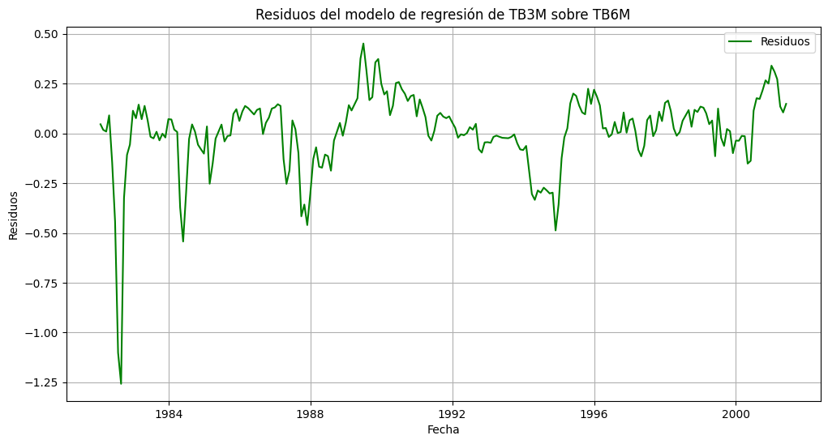

```python
import matplotlib.pyplot as plt

# ... (código para estimar el modelo de regresión de TB3M sobre TB6M) ...

# Gráfica de los residuos
plt.figure(figsize=(12, 6))
plt.plot(residuals.index, residuals, label='Residuos', color='green')
plt.title('Residuos del modelo de regresión de TB3M sobre TB6M')
plt.xlabel('Fecha')
plt.ylabel('Residuos')
plt.legend()
plt.grid(True)
plt.show()
```

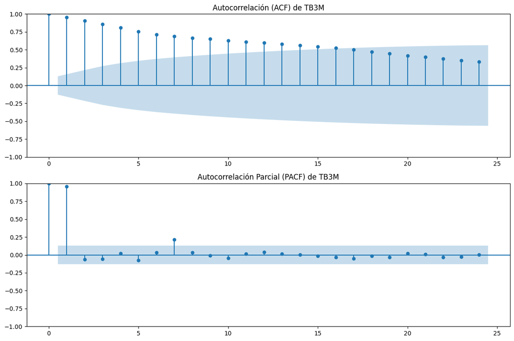

```python
from statsmodels.graphics.tsaplots import plot_acf, plot_pacf

# Gráficas ACF y PACF para TB3M
fig, axes = plt.subplots(2, 1, figsize=(12, 8))
plot_acf(df['TB3M'], ax=axes[0])
plot_pacf(df['TB3M'], ax=axes[1])
axes[0].set_title('Autocorrelación (ACF) de TB3M')
axes[1].set_title('Autocorrelación Parcial (PACF) de TB3M')
plt.tight_layout()
plt.show()

# Gráficas ACF y PACF para TB6M (código similar al anterior, cambiando 'TB3M' por 'TB6M')
```

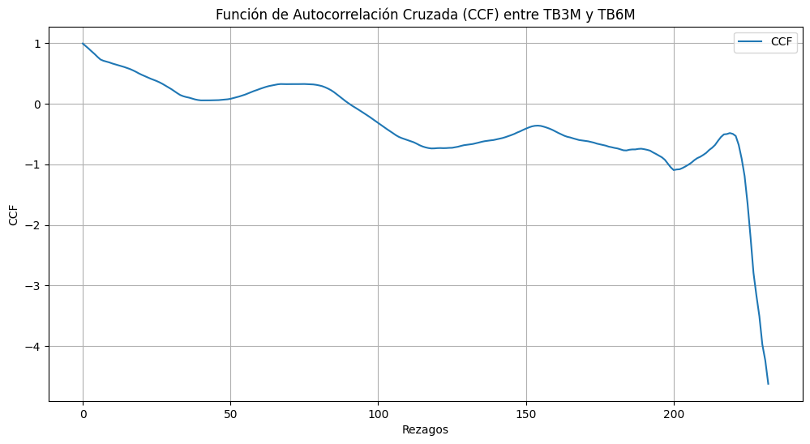

```python
from statsmodels.tsa.stattools import ccf

# Calcula la CCF
ccf_values = ccf(df['TB3M'], df['TB6M'])

# Gráfica de la CCF
plt.figure(figsize=(12, 6))
plt.plot(ccf_values, label='CCF')
plt.title('Función de Autocorrelación Cruzada (CCF) entre TB3M y TB6M')
plt.xlabel('Rezagos')
plt.ylabel('CCF')
plt.legend()
plt.grid(True)
plt.show()
```

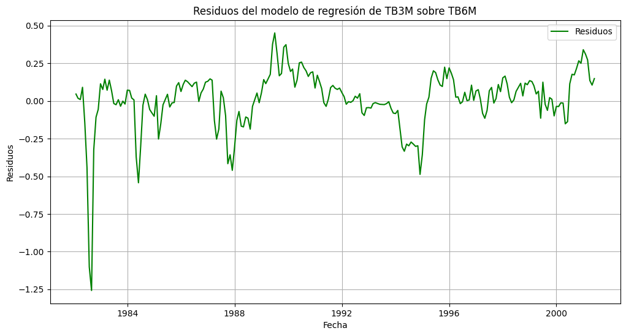

```python
# ... (Código previo para cargar datos, realizar pruebas ADF, etc.) ...

# Estimación del modelo de regresión de TB3M sobre TB6M
from statsmodels.regression.linear_model import OLS
y = df['TB3M']
X = df[['TB6M']]
model = OLS(y, X).fit()
residuals = model.resid

# Gráfica de los residuos
import matplotlib.pyplot as plt
plt.figure(figsize=(12, 6))
plt.plot(residuals.index, residuals, label='Residuos', color='green')
plt.title('Residuos del modelo de regresión de TB3M sobre TB6M')
plt.xlabel('Fecha')
plt.ylabel('Residuos')
plt.legend()
plt.grid(True)
plt.show()

# ... (Código para generar las otras gráficas: ACF, PACF, CCF) ...
```